# DataAnalytics_P2

Data Analysis Steps:

1. Question phase
2. Wrangling : a) Data Acquisition Phase, b) Data investigation
3. Data exploration
4. Draw conslusion
5. Communication Phase

Step1 : Question Phase

Questions that can be answered using the dataset

1. Factors that contributes to Survival, like no of children/siblings/parents, place of boarding the Ship, economic status.

Step2 : Wrangling - Data Acquisition

```python
# importing numpy and pandas and plotting library
import numpy as np
import pandas as pd
import matplotlib.pyplot as plt
%matplotlib inline


titanic_data_df = pd.read_csv('titanic.csv')
```

Step2 : Wrangling - Data investigation

```python
#function to print the starting 5 rows of given dataframe
def print_head_rows(titanic_df):
    print titanic_df.head()

#function to print all columns of the dataframe
def print_column(titanic_df):
    print titanic_df.columns
```

```python
print_column(titanic_data_df)
```

```
Index([u'PassengerId', u'Survived', u'Pclass', u'Name', u'Sex', u'Age',
       u'SibSp', u'Parch', u'Ticket', u'Fare', u'Cabin', u'Embarked'],
      dtype='object')
```

Step3 : Data Exploration

```python
print_head_rows(titanic_data_df)
```

```
   PassengerId  Survived  Pclass  \
0            1         0       3
1            2         1       1
2            3         1       3
3            4         1       1
4            5         0       3

                                                Name     Sex  Age  SibSp  \
0                            Braund, Mr. Owen Harris    male   22      1
1  Cumings, Mrs. John Bradley (Florence Briggs Th...  female   38      1
2                             Heikkinen, Miss. Laina  female   26      0
3       Futrelle, Mrs. Jacques Heath (Lily May Peel)  female   35      1
4                           Allen, Mr. William Henry    male   35      0

   Parch            Ticket     Fare Cabin Embarked
0      0         A/5 21171   7.2500   NaN        S
1      0          PC 17599  71.2833   C85        C
2      0  STON/O2. 3101282   7.9250   NaN        S
3      0            113803  53.1000  C123        S
4      0            373450   8.0500   NaN        S
```

```python
#checking data for NaN values
print titanic_data_df.isnull().sum()
```

```
PassengerId      0
Survived         0
Pclass           0
Name             0
Sex              0
Age            177
SibSp            0
Parch            0
Ticket           0
Fare             0
Cabin          687
Embarked         2
dtype: int64
```

With above exploration we can see Age has null values in it. Lets see some of those values

There are total 177 data rows where age is NaN

```python
print titanic_data_df.tail()
```

```
     PassengerId  Survived  Pclass                                      Name  \
886          887         0       2                     Montvila, Rev. Juozas
887          888         1       1              Graham, Miss. Margaret Edith
888          889         0       3  Johnston, Miss. Catherine Helen "Carrie"
889          890         1       1                     Behr, Mr. Karl Howell
890          891         0       3                       Dooley, Mr. Patrick

        Sex  Age  SibSp  Parch      Ticket   Fare Cabin Embarked
886    male   27      0      0      211536  13.00   NaN        S
887  female   19      0      0      112053  30.00   B42        S
888  female  NaN      1      2  W./C. 6607  23.45   NaN        S
889    male   26      0      0      111369  30.00  C148        C
890    male   32      0      0      370376   7.75   NaN        Q
```

There exists many solutions to above age NaN problem:

1. Replace NaN with average of all ages
2. Replace NaN with Mod values
3. Replace NaN with 0, since it is very hard to guess the age
4. Remove the passenges with NaN age values

As understood by me I will choose option4, i.e., removing the records with age value is NaN. Since replacing NaN age values with average might affect the data the way we dont wanted it, also I wanted to keep the relationship of age with other columns same without aletring them.

```python
# titanic_data_df["Age"] = titanic_data_df["Age"].fillna(titanic_data_df.mean()["Age"].round())

titanic_data_df = titanic_data_df[pd.notnull(titanic_data_df["Age"])]
```

```python
# print titanic_data_df.tail()

print titanic_data_df.isnull().sum()
```

```
PassengerId      0
Survived         0
Pclass           0
Name             0
Sex              0
Age              0
SibSp            0
Parch            0
Ticket           0
Fare             0
Cabin          529
Embarked         2
dtype: int64
```

But after looking into documentation about the column, it was found that the NaN value represents that those passenger didn't have the cabin, which make sense.

Since in the exploration of data we won't require cabin number, I will transform the Cabin column into boolean column i.e. those having cabin number will be True otherwise False.

```python
# chaning Cabin column data
# if cabin number exists then True, otherwise False

titanic_data_df[['Cabin']] = ~titanic_data_df[['Cabin']].isnull()
```

```python
print_head_rows(titanic_data_df)
```

```
   PassengerId  Survived  Pclass  \
0            1         0       3
1            2         1       1
2            3         1       3
3            4         1       1
4            5         0       3

                                                Name     Sex  Age  SibSp  \
0                            Braund, Mr. Owen Harris    male   22      1
1  Cumings, Mrs. John Bradley (Florence Briggs Th...  female   38      1
2                             Heikkinen, Miss. Laina  female   26      0
3       Futrelle, Mrs. Jacques Heath (Lily May Peel)  female   35      1
4                           Allen, Mr. William Henry    male   35      0

   Parch            Ticket     Fare  Cabin Embarked
0      0         A/5 21171   7.2500  False        S
1      0          PC 17599  71.2833   True        C
2      0  STON/O2. 3101282   7.9250  False        S
3      0            113803  53.1000   True        S
4      0            373450   8.0500  False        S
```

```python
print titanic_data_df.isnull().sum()
```

```
PassengerId    0
Survived       0
Pclass         0
Name           0
Sex            0
Age            0
SibSp          0
Parch          0
Ticket         0
Fare           0
Cabin          0
Embarked       2
dtype: int64
```

Also since I am looking to explore the relationship between survival and number of people in family, we need a single value which tells what is the famly size

Creating a new column Familysize = self + number of parents + number of kids/siblings

```python
## adding a new column family size, contains total family size
titanic_data_df['Familysize'] = titanic_data_df['SibSp'] + titanic_data_df['Parch'] + 1
```

```python
print_head_rows(titanic_data_df)
```

```
   PassengerId  Survived  Pclass  \
0            1         0       3
1            2         1       1
2            3         1       3
3            4         1       1
4            5         0       3

                                                Name     Sex  Age  SibSp  \
0                            Braund, Mr. Owen Harris    male   22      1
1  Cumings, Mrs. John Bradley (Florence Briggs Th...  female   38      1
2                             Heikkinen, Miss. Laina  female   26      0
3       Futrelle, Mrs. Jacques Heath (Lily May Peel)  female   35      1
4                           Allen, Mr. William Henry    male   35      0

   Parch            Ticket     Fare  Cabin Embarked  Familysize
0      0         A/5 21171   7.2500  False        S           2
1      0          PC 17599  71.2833   True        C           2
2      0  STON/O2. 3101282   7.9250  False        S           1
3      0            113803  53.1000   True        S           2
4      0            373450   8.0500  False        S           1
```

### Investigating survival based on familysize

```python
# dividing data on basis of familysize and then taking mean of survival rate
print titanic_data_df.groupby(['Familysize']).mean()[['Survived']] * 100
```

```
             Survived
Familysize
1           32.178218
2           54.676259
3           56.989247
4           77.777778
5           27.272727
6           13.636364
7           33.333333
8            0.000000
```

The line plot also displays the same thing, i.e. single people had ~30% survival rate, and people with families of size 2 to 4 had high survival rate. And as family size increases the survival rate decreases.

```python
## funtion to return specific value from the dataframe based on given row and column values

def converts_dataframe_to_values(df, selector1, selector2):
    return df.loc[selector1, selector2]
```

Exploration points: From above results, when we divide the full data based on "family size column", we can see some normal and some weird trends. Like maximum people were travelling alone and people with very large families are very less. The weird finding is that number of people travelling alone have less survival rate as compared to people travelling with small families. The survival rate of single pasenger is just 30%, which is against the natural thought that single person can get adjusted any where and save themselves. But here the trends shows that people with family size of 2,3 and 4 were safest.

Also the large size families were not safe. Families with size greater then 4, were having survival rate even less then 35%.

The reason could be that family will have females and children, so they were given preference over single people. But for larger family it would have been hard to adjust so many people together because they all wanted to go together.

Below charts also depicts the same findings.

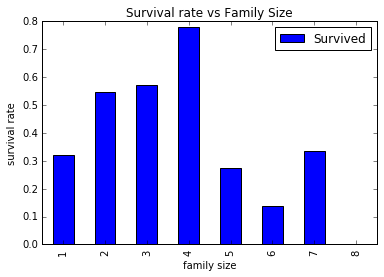

```python
plot_data = titanic_data_df.groupby(['Familysize']).mean()[['Survived']].plot(kind="bar",\
 title="Survival rate vs Family Size");
plot_data.set_xlabel("family size");
plot_data.set_ylabel("survival rate");
```

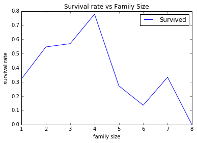

```python
#this is line chart representation of above data

plot_data = titanic_data_df.groupby(['Familysize']).mean()[['Survived']].plot(kind="line",\
 title="Survival rate vs Family Size");
plot_data.set_xlabel("family size");
plot_data.set_ylabel("survival rate");
```

### Investigating survival based on passengers Gender

```python
titanic_age_df = titanic_data_df.groupby(['Sex', 'Survived'])
```

```python
titanic_age_passenger_count_df = titanic_age_df.count()[['PassengerId']]

print titanic_age_passenger_count_df
```

```
                 PassengerId
Sex    Survived
female 0                  64
       1                 197
male   0                 360
       1                  93
```

```python
#rate of survival of female and male passengers
female_survived = converts_dataframe_to_values(titanic_age_passenger_count_df,'female', 1 )
male_survived = converts_dataframe_to_values(titanic_age_passenger_count_df, 'male', 1)

male_survival_rate = (male_survived / titanic_data_df[titanic_data_df['Sex'] == 'male'].count()[['PassengerId']]) * 100
female_survival_rate = (female_survived / titanic_data_df[titanic_data_df['Sex'] == 'female'].count()[['PassengerId']]) \
* 100

print female_survival_rate
print male_survival_rate
```

```
PassengerId    75.478927
dtype: float64
PassengerId    20.529801
dtype: float64
```

Exploration : gender did played a role in survival, the rate of female survived of all the female is greater then the rate of male survived of all males. As we see above in the survival rate, ~75% females survived as compared to ~20% male.

### Investigating survival based on passengers Embarked

```python
# Count of passengers boarding from different embarked ports
print titanic_data_df.groupby('Embarked').count()[['PassengerId']]

passenger_count_c = titanic_data_df.groupby('Embarked').count()[['PassengerId']].loc[['C']]
passenger_count_q = titanic_data_df.groupby('Embarked').count()[['PassengerId']].loc[['Q']]
passenger_count_s = titanic_data_df.groupby('Embarked').count()[['PassengerId']].loc[['S']]
```

```
          PassengerId
Embarked
C                 130
Q                  28
S                 554
```

From above data we can see that Embarkation port S(Southampton) has highest number of passengers boarding. Lets try to find does this trend continues into survival data too.

```python
#overall passenger survival average
print titanic_data_df[['Survived']].mean() * 100
```

```
Survived    40.616246
dtype: float64
```

```python
#average survival rate of all 3 embarked ports
print titanic_data_df.groupby('Embarked').mean()[['Survived']] * 100
```

```
           Survived
Embarked
C         60.769231
Q         28.571429
S         36.281588
```

We can clearly see that Southampton(36%) and Queenstown(28%) have survival rate close to the overall survial rate (40%), but survival rate of Cherbourg(60%) is high. Lets try to figure out the reason for this.

So our above assumption that Southampton, where maximum boarded will have the maximum survival rate has proved to be wrong. First reason that I can thought about is may be number of female passengers from Cherbourg were more as compared to other ports.

So lets see if this survival rate has something to do with females passengers.

```python
titanic_embarked_gender_data = titanic_data_df.groupby(['Embarked', 'Sex']).count()[['PassengerId']]
print titanic_embarked_gender_data
```

```
                 PassengerId
Embarked Sex
C        female           61
         male             69
Q        female           12
         male             16
S        female          186
         male            368
```

```python
# Printing %age of female candidates boarded from different ports, earlier we saw that female candidates have higher
# survival rate, so any port with higher %age of female candidate might lead to higher survival rate (definetly there
# will be other factors affecting)

print "%age Female passengers boarded from Cherbourg : "
print (titanic_embarked_gender_data.loc['C', 'female']/ titanic_embarked_gender_data.loc[['C']].sum()) * 100;
print ""
print "%age Female passengers boarded from Queenstown : "
print (titanic_embarked_gender_data.loc['Q', 'female']/ titanic_embarked_gender_data.loc[['Q']].sum()) * 100;
print ""
print "%age Female passengers boarded from Southampton : "
print (titanic_embarked_gender_data.loc['S', 'female']/ titanic_embarked_gender_data.loc[['S']].sum()) * 100;
```

```
%age Female passengers boarded from Cherbourg :
PassengerId    46.923077
dtype: float64

%age Female passengers boarded from Queenstown :
PassengerId    42.857143
dtype: float64

%age Female passengers boarded from Southampton :
PassengerId    33.574007
dtype: float64
```

%age of female candidates boarded from Cherbourg is not exponentially high that can affect the result, we need to look for something else.

Next I would like to see the money factor (People given higher fare vs People given lower fare)

I would like to see that according to my assumption, people who has given higher fare might be safer.

Lets see about this factor.

```
               Fare
Embarked
C         68.296767
Q         18.265775
S         27.476284
```

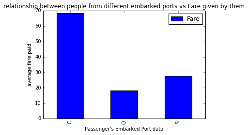

```python
## people with average fare from different embarked
print titanic_data_df.groupby(['Embarked']).mean()[['Fare']]

data_plot = titanic_data_df.groupby(['Embarked']).mean()[['Fare']].plot(kind='bar', \
   title="relationship between people from different embarked ports vs Fare given by them");
data_plot.set_xlabel("Passenger's Embarked Port data");
data_plot.set_ylabel("average fare paid");
```

Above the data clearly shows that people from Cherbourg is paying higher average fare as compared to other embarked port's people. There could be a correlation between this.

Now I wanted to make sure is familysize affects the fare, i.e people with larger families paying higher fare.

```python
print titanic_data_df.groupby(['Familysize']).mean()[['Fare']]
```

```
                 Fare
Familysize
1           22.644212
2           51.596766
3           41.744624
4           57.191511
5           69.959091
6           73.722727
7           29.366667
8           46.900000
```

there are no direct co-relation between familysize and fare so, I have to discard this assumption, i.e. larger families not necessarily paying higher fare.

Now we have to investigate more on the relation between fare and survival rate. Having more money can save your life? Lets find out.

```
          Survived       Fare
Embarked
C         0.607692  68.296767
Q         0.285714  18.265775
S         0.362816  27.476284
```

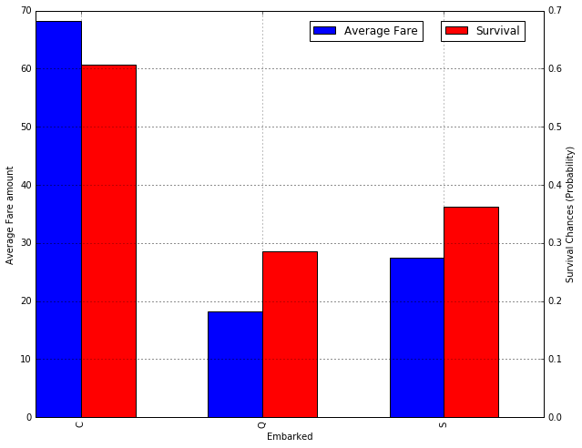

```python
#Lets find direct comparison between fare and survival rate
# As our previous findings this should be a direct corelation.

print titanic_data_df.groupby(['Embarked']).mean()[['Survived', 'Fare']]

fig = plt.figure()
ax = fig.add_subplot(111)
ax2 = ax.twinx()

width = 0.3

df_survived = titanic_data_df.groupby(['Embarked']).mean()[["Survived"]]
df_fare = titanic_data_df.groupby(['Embarked']).mean()[["Fare"]]

df_fare.plot(kind='bar',color='blue',grid=True,ax=ax,width=width,position=1,figsize=(10, 8))
df_survived.plot(kind='bar',color='red',ax=ax2,grid=True,width=width, position=0,figsize=(10, 8))

ax.set_ylabel('Average Fare amount')
ax2.set_ylabel('Survival Chances (Probability)')

ax.legend(["Average Fare"], loc="center", bbox_to_anchor=(0.65, 0.95))
ax2.legend(["Survival"],loc="center", bbox_to_anchor=(0.88, 0.95))

fig.show()
```

Above data and Bar chart clearly shows that there is a direct relationship between average fare and survival rate. If average fare is high survival rate will be high and if average fare is low survival rate will be low.

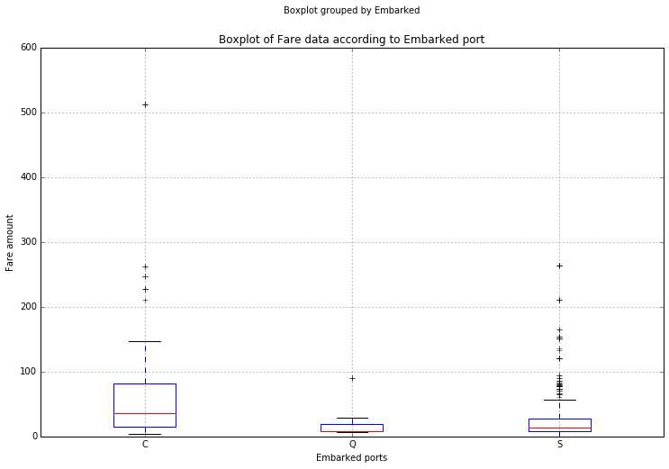

```python
#Also trying to see from where maximum rich people boarded the ship. (I am assuming richness is directly
#proportional to Fare spent by person)

pp = plt.figure();
data_plot = pd.DataFrame(titanic_data_df[["Fare", "Embarked"]]);
db = data_plot.boxplot(by='Embarked', figsize=(12,8));
plt.title("Boxplot of Fare data according to Embarked port");
plt.ylabel("Fare amount");
plt.xlabel("Embarked ports");
```

I wanted to know if Cherbourg people are paying highest average fare are they richest people. To see the richest people we need to see the Pclass of each embarked port, Pclass represents the financial status of people, with Pclass == 1 => Highest financial status Pclass == 2 => Middle financial status Pclass == 3 => Lower financial status

```python
print titanic_data_df.groupby(['Embarked', "Pclass"]).count()[["PassengerId"]]
```

```
                 PassengerId
Embarked Pclass
C        1                74
         2                15
         3                41
Q        1                 2
         2                 2
         3                24
S        1               108
         2               156
         3               290
```

```python
def useapply(x):
    count = x.count()
    print (x.groupby("Pclass").count()/count)["PassengerId"][1] * 100


print "Pclass 1 %age for different Embarked:"
titanic_data_df.groupby(['Embarked']).apply(useapply)
```

```
Pclass 1 %age for different Embarked:
56.9230769231
56.9230769231
7.14285714286
19.4945848375
```

Above there are 4 values, 1st value is repeated, so technically there are 3 values, 1st value is for Embarked Cherbourg => Pclass == 1 is 56.9230769231% 2nd value is for Embarked Queenstown => Pclass == 1 is 7.14285714286% 3rd value is for Embarked Southampton => Pclass == 1 is 19.4945848375%

In the above dataset we can clearly see that passenger paying extra money for fare are more rich and are having greater chance of survival and above we have seen people from Cherbourg are paying higher average fare, so there exists a corelation between money spent on Fare and survival. Chance of survival is higher if someone is rich.

Boxplot and barchart drawn above also support our claim.

Answer to above question is yes, people boarded from Cherbourg, who were more rich(from my findings above by giving more fare) are ahead in surviving too. ~60% people from Cherbourg survived.

```python
Step4: Conclusion
```

We can see above that passengers travelling alone were having less chances of survival as compared to passengers with family of size upto 4. Trends in the above results are clear that people travelling with family were safe in titanic as compared to people travelling alone, but if family size goes beyond 5 or more then they were not safe. The reason behind it could be that family were given preferences over single people. Also larger families with size above 5 would have taken more space thats why they had low survival rate. There is a corelation between small family size and survival.

Females are given preferences over male by a large margin.

These corelation doesn't leads to causation, as the actual situation at that moment would be very difficult and different, as when it comes to survival people tends to do anything. But these findings can make us guess what was the scenario at that moment and what someone could have done to increase the chances of survival.

References :

1. http://matplotlib.org/examples/pylab_examples/barchart_demo.html for visualization
2. http://pandas.pydata.org/pandas-docs/stable/generated/pandas.DataFrame.plot.html